# Analyzing the horizontal orientation of the crustal stress adjacent to plate boundaries

3 - Orientation analysis in the Pole of Rotation (PoR) Reference Frame

Tobias Stephan

2023-08-06

```r
data("san_andreas")
#san_andreas <- filter(san_andreas, regime == "S")
head(san_andreas)
```

```
## Simple feature collection with 6 features and 9 fields
## Geometry type: POINT
## Dimension:     XY
## Bounding box:  xmin: -119.966 ymin: 32.94 xmax: -115.627 ymax: 35.714
## Geodetic CRS:  WGS 84
## # A tibble: 6 × 10
##   id         lat   lon   azi   unc type  depth quality regime
##   <chr>    <dbl> <dbl> <dbl> <dbl> <chr> <dbl> <fct>   <chr>
## 1 wsm07786  35.7 -120.    36     1 HF      1.3 A       S
## 2 wsm11750  32.9 -116.     7     1 FMF     7   A       S
## 3 wsm11759  33.0 -116.   169     1 FMF     5   A       S
## 4 wsm11782  33.2 -116.     1     1 FMF     8   A       S
## 5 wsm11801  33.9 -116.    23     1 FMF     6   A       S
## 6 wsm11830  33.5 -116.   160     1 FMF     9   A       S
## # ℹ 1 more variable: geometry <POINT [°]>
```

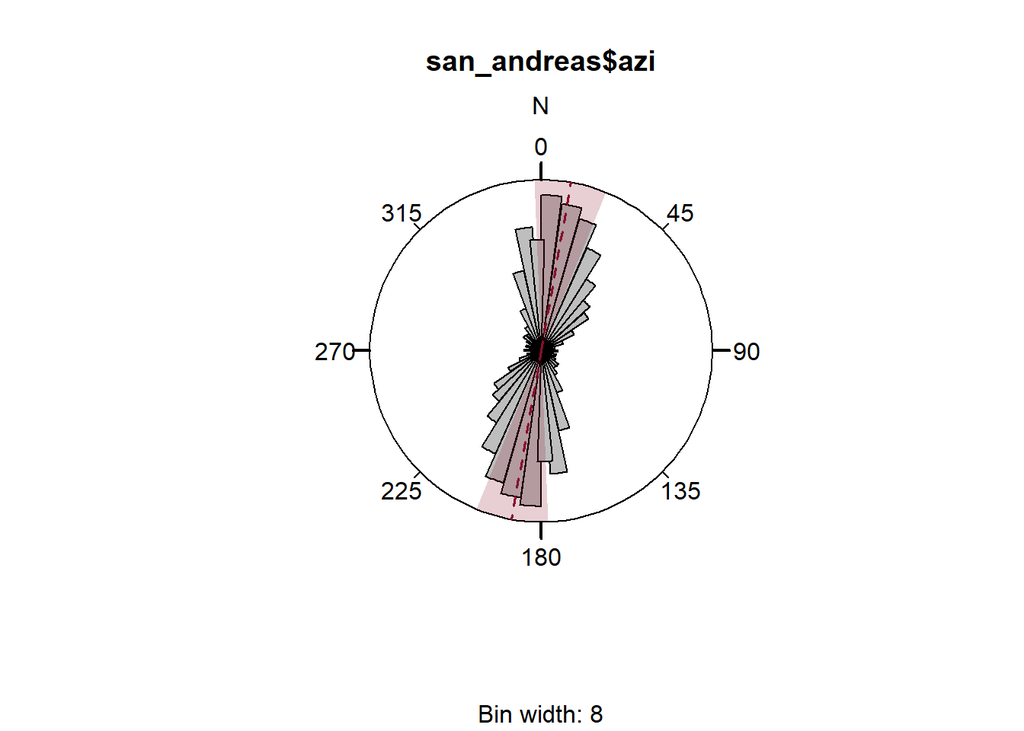

```r
rose(san_andreas$azi, weights = 1 / san_andreas$unc)
```

Let’s visualize the spatial distribution of the stress measurements.

```r
countries <- rnaturalearth::ne_countries(50, returnclass = "sf")

map <- ggplot() +
  geom_sf(data = countries, fill = "grey80", alpha = .5) +
  geom_sf(
    data = plates,
    color = "red",
    lwd = 2,
    alpha = .5
  ) +
  scale_alpha_discrete(name = "Quality rank", range = c(1, 0.4)) +
  theme_minimal()
```

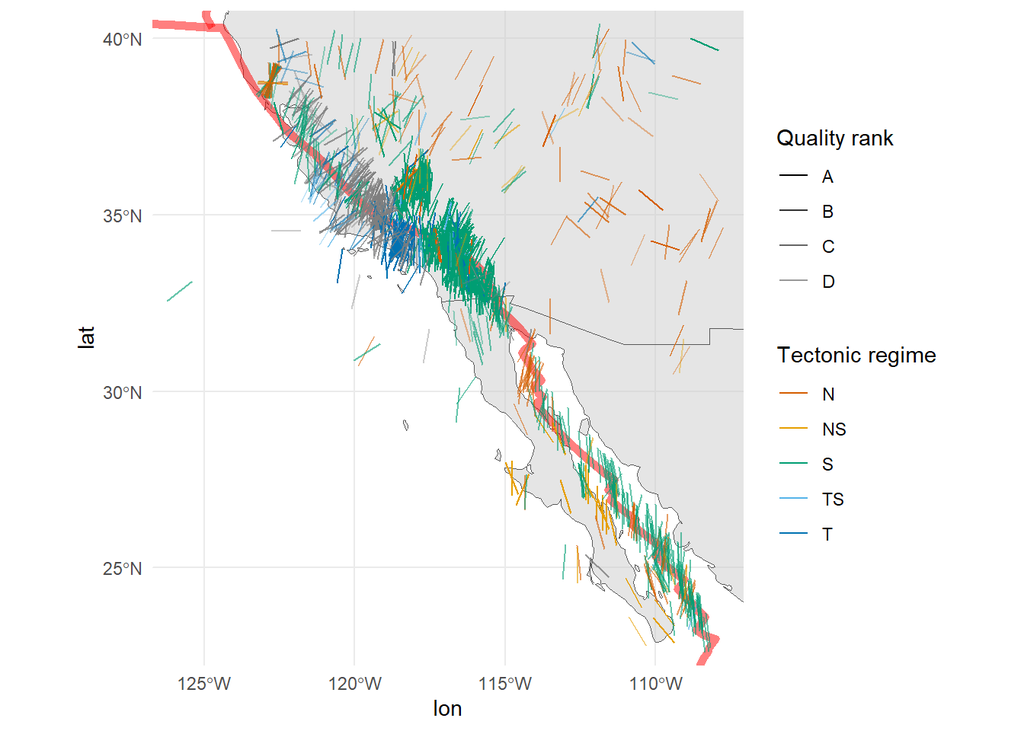

```r
map +
  geom_spoke(
    data = san_andreas,
    aes(
      x = lon,
      y = lat,
      angle = deg2rad(90 - azi),
      color = regime,
      alpha = quality
    ),
    radius = .5,
    position = "center_spoke",
    na.rm = TRUE
  ) +
  scale_color_manual(
    name = "Tectonic regime", values = stress_colors(),
    breaks = names(stress_colors())
    ) +
  coord_sf(
    xlim = range(san_andreas$lon),
    ylim = range(san_andreas$lat)
  )
```

Modeling the stress directions (wrt. to the geographic North pole) using the Pole of Rotation (PoR) of the motion of North America relative to the Pacific Pate. We test the dataset against a right-laterally tangential displacement type.

```r
data("nuvel1")
por <- subset(nuvel1, nuvel1$plate.rot == "na")
san_andreas_prd <- PoR_shmax(san_andreas, por, type = "right")
```

Combine the model results with the coordinates of the observed data

```r
san_andreas_res <- data.frame(
  sf::st_drop_geometry(san_andreas),
  san_andreas_prd
)
```

## Statistical evaluation of the fit

The rose diagram displays the frequency distribution of the transformed azimuths:

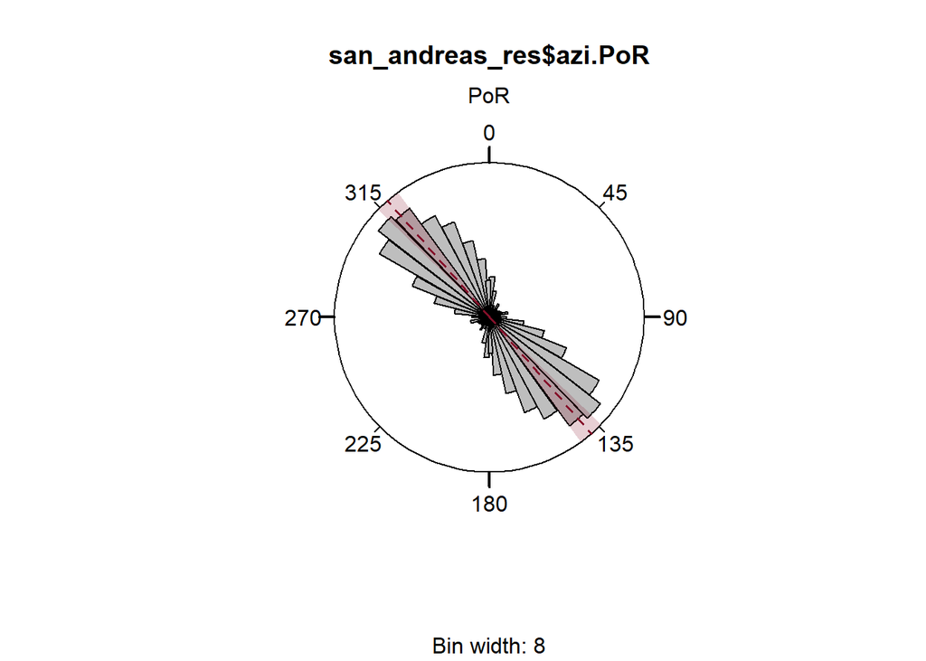

```r
rose(san_andreas_res$azi.PoR, weights = 1 / san_andreas$unc, mtext = "PoR")
```

### Mean direction of transformed azimuths

```r
circular_mean(san_andreas_res$azi.PoR, w = 1 / san_andreas_res$unc)
```

```
## [1] 138.8937
```

```r
circular_sd(san_andreas_res$azi.PoR, w = 1 / san_andreas_res$unc)
```

```
## [1] 37.12227
```

```r
circular_median(san_andreas_res$azi.PoR, w = 1 / san_andreas_res$unc)
```

```
## [1] 137.0094
```

```r
circular_var(san_andreas_res$azi.PoR, w = 1 / san_andreas_res$unc)
```

```
## [1] 0.1893274
```

### Circular Dispersion

The (weighted) circular dispersion of the orientation angles around the prediction $D_w (\sigma_{Hmax}, \sigma_{\text{PB}})$ can be measured by:

```r
circular_dispersion(san_andreas_res$azi.PoR, 135, w = san_andreas_res$unc)
```

```
## [1] 0.1799527
```

### Confidence interval

Assuming a von Mises Distribution (circular normal distribution) of the orientation data, a $(1-\alpha \%)/100$ confidence interval can be calculated (Mardia and Jupp, 1999):

```r
confidence_interval(
  san_andreas_res$azi.PoR,
  conf.level = 0.95,
  w = 1 / san_andreas_res$unc
)
```

```
## $mu
## [1] 138.8937
##
## $conf.angle
## [1] 4.972762
##
## $conf.interval
## [1] 133.9209 143.8665
```

The prediction for the transformed $\sigma_{SHmax}$ orientation is $\sigma_{\text{PB}} = 135^{\circ}$. Since the prediction $\sigma_{\text{PB}}$ lies within the confidence interval, it can be concluded with 95% confidence that the orientations follow the predicted trend.

## Spatial distribution of the misfit from the predicted orientations

`ggplot2::ggplot()` can be used to visualize the results. The orientation of the axis can be displayed with the function `geom_spoke()`. The position argument `position = "center_spoke"` aligns the marker symbol at the center of the point. The deviation can be color coded. `deviation_norm()` yields the normalized value of the deviation, i.e. absolute values between 0 and 90$^{\circ}$.

Also included are the plate boundary geometries after Bird (2003):

```r
data("plates") # load plate boundary data set
```

Alternatively, there is also the NUVEL1 plate boundary model by DeMets et al. (1990) stored under `data("nuvel1_plates")`.

First we create the predicted trajectories of $\sigma_{\text{PB}}$:

```r
trajectories <- eulerpole_loxodromes(por, 40, cw = FALSE)
```

…and add the $\sigma_{\text{PB}}$ trajectories and data points to our map:

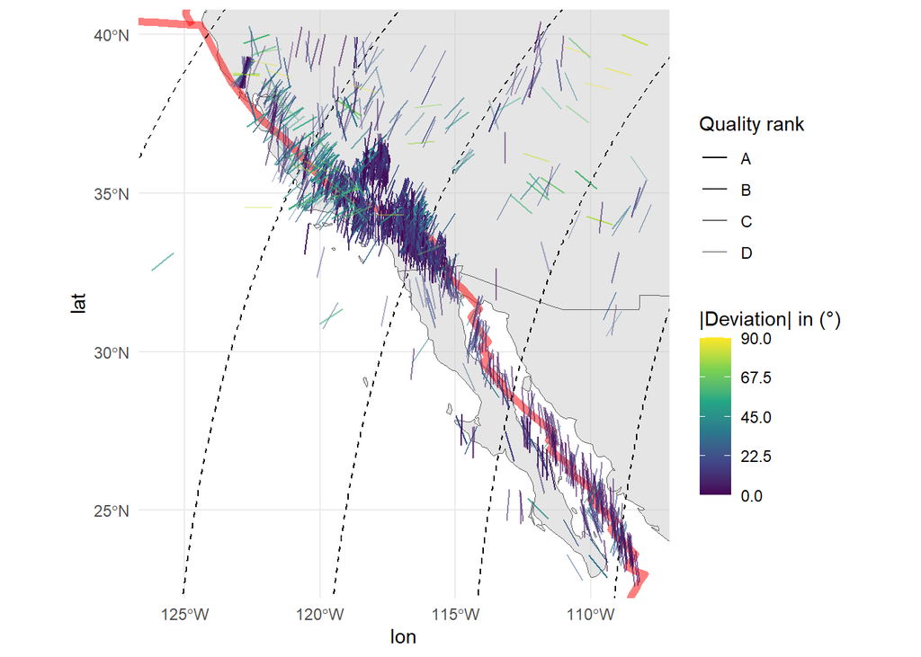

```r
map +
  geom_sf(
    data = trajectories,
    lty = 2
  ) +
  geom_spoke(
    data = san_andreas_res,
    aes(
      x = lon,
      y = lat,
      angle = deg2rad(90 - azi),
      color = deviation_norm(dev),
      alpha = quality
    ),
    radius = .5,
    position = "center_spoke",
    na.rm = TRUE
  ) +
  scale_color_continuous(
    type = "viridis",
    limits = c(0, 90),
    name = "|Deviation| in (\u00B0)",
    breaks = seq(0, 90, 22.5)
  ) +
  coord_sf(
    xlim = range(san_andreas$lon),
    ylim = range(san_andreas$lat)
  )
```

## Variation of the Direction of the Maximum Horizontal Stress wrt. to the Distance to the Plate Boundary

The direction of the maximum horizontal stress correlates with plate motion direction at the plate boundary zone. Towards the plate interior, plate boundary forces become weaker and other stress sources will probably dominate.

To visualize the variation of the $\sigma_{Hmax}$ wrt. to the distance to the plate boundary, we need to transfer the direction of $\sigma_{Hmax}$ from the geographic reference system (i.e. azimuth is the deviation of a direction from geographic North pole) to the **Pole of Rotation (PoR)** reference system (i.e. azimuth is the deviation from the PoR).

> The *PoR coordinate reference system* is the oblique transformation of the geographical coordinate system with the PoR coordinates being the the translation factors.

The azimuth in the *PoR reference system* $\alpha_{PoR}$ is the angular difference between the azimuth in geographic reference system $\alpha_{geo}$ and the (initial) bearing of the great circle that passes through the data point and the PoR $\theta$.

To calculate the distance to the plate boundary, both the plate boundary geometries and the data points (in geographical coordinates) will be transformed in to the *PoR* reference system. In the *PoR* system, the distance is the latitudinal or longitudinal difference between the data points and the inward/outward or tangential moving plate boundaries, respectively.

This is done with the function `distance_from_pb()`, which returns the angular distances.

```r
plate_boundary <- subset(plates, plates$pair == "na-pa")

san_andreas_res$distance <- distance_from_pb(
    x = san_andreas,
    PoR = por,
    pb = plate_boundary,
    tangential = TRUE
  )
```

Finally, we visualize the $\sigma_{Hmax}$ direction wrt. to the distance to the plate boundary:

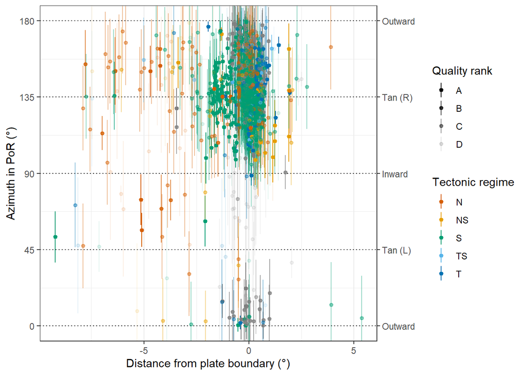

```r
azi_plot <- ggplot(san_andreas_res, aes(x = distance, y = azi.PoR)) +
  coord_cartesian(ylim = c(0, 180)) +
  labs(x = "Distance from plate boundary (\u00B0)", y = "Azimuth in PoR (\u00B0)") +
  geom_hline(yintercept = c(0, 45, 90, 135, 180), lty = 3) +
  geom_pointrange(
    aes(
      ymin = azi.PoR - unc, ymax = azi.PoR + unc,
      color = san_andreas$regime, alpha = san_andreas$quality
    ),
    size = .25
  ) +
  scale_y_continuous(
    breaks = seq(-180, 360, 45),
    sec.axis = sec_axis(
      ~.,
      name = NULL,
      breaks = c(0, 45, 90, 135, 180),
      labels = c("Outward", "Tan (L)", "Inward", "Tan (R)", "Outward")
    )
  ) +
  scale_alpha_discrete(name = "Quality rank", range = c(1, 0.1)) +
  scale_color_manual(
    name = "Tectonic regime", values = stress_colors(), breaks = names(stress_colors())
    ) +
  theme_bw()
print(azi_plot)
```

Adding a rolling statistics (e.g. weighted mean and 95% confidence interval) of the transformed azimuth:

```r
san_andreas_roll <- dplyr::arrange(san_andreas_res, distance)

san_andreas_roll$r_mean <- roll_circstats(
  san_andreas_roll$azi.PoR,
  w = 1 / san_andreas_roll$unc,
  FUN = circular_mean,
  width = 51
)

san_andreas_roll$r_conf95 <- roll_confidence(
  san_andreas_roll$azi.PoR,
  w = 1 / san_andreas_roll$unc,
  width = 51
) / 2
```

Plot:

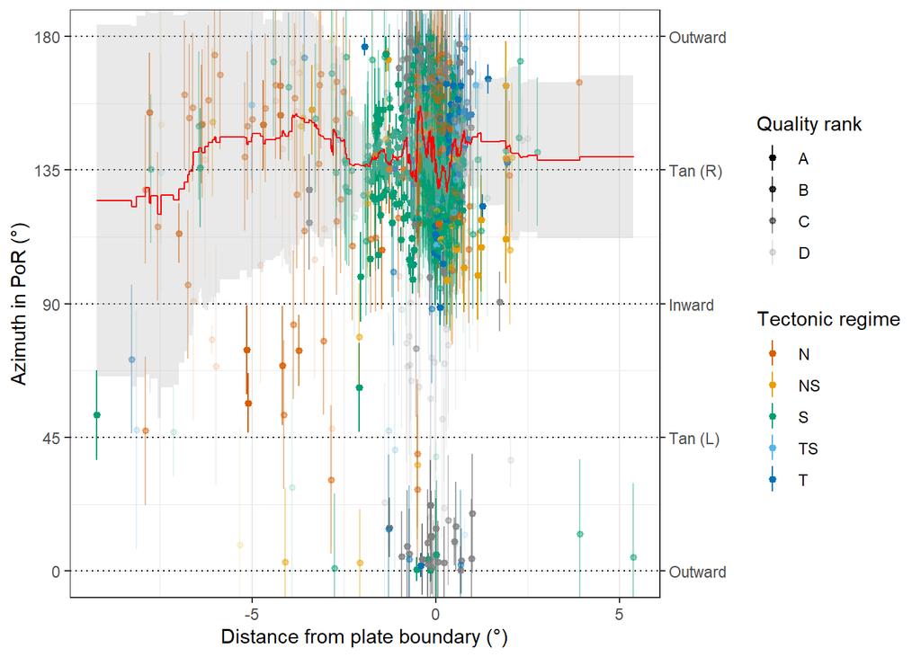

```r
azi_plot +
  pammtools::geom_stepribbon(
    data = san_andreas_roll,
    aes(x = distance, ymin = r_mean - r_conf95, ymax = r_mean + r_conf95),
    color = NA, fill = "grey", alpha = 1 / 3
  ) +
  geom_step(
    data = san_andreas_roll,
    aes(distance, r_mean),
    color = "red"
  )
```

Close to the dextral plate boundary, the majority of the stress data have a strike-slip fault regime and are oriented around 135$^{\circ}$ wrt. to the PoR. Thus, the date are parallel to the predicted stress $\sigma_{\text{PB}}$ sourced by a right-lateral displaced plate boundary. Away from the plate boundary, the data becomes more noisy.

> This azimuth (PoR) vs. distance plot also allows to identify whether a less known plate boundary represents a inward, outward, or tangential displaced boundary.

The relationship between the azimuth and the distance can be better visualized by using the deviation (normalized by the data precision) from the the predicted stress direction $\sigma_{\text{PB}}$, i.e. dispersion $D$:

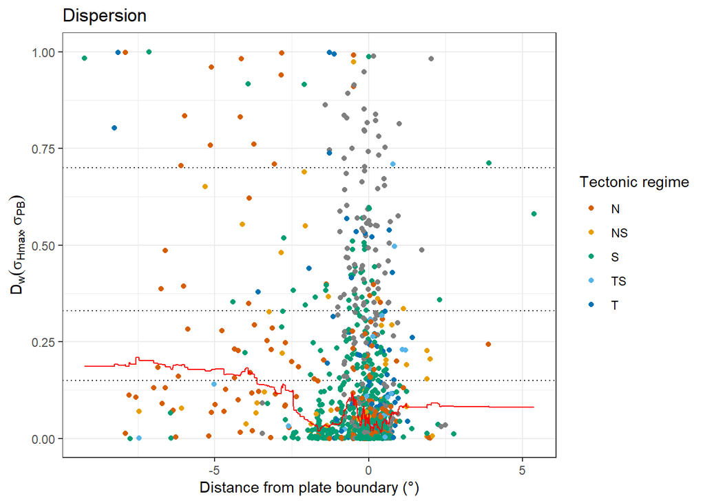

```r
# Rolling norm chisq:
san_andreas_roll$roll_disp <- roll_dispersion(
 x = san_andreas_roll$azi.PoR,
  y = san_andreas_roll$prd,
  w = 1 / san_andreas_roll$unc,
  width = 51
)

# plotting:
ggplot(san_andreas_res, aes(x = distance, y = cdist)) +
  coord_cartesian(ylim = c(0, 1)) +
  labs(
    x = "Distance from plate boundary (\u00B0)",
    y = expression(D[w](sigma["Hmax"], sigma["PB"]))
    ) +
  geom_hline(yintercept = c(0.15, .33, .7), lty = 3) +
  geom_point(aes(color = san_andreas_res$regime)) +
  scale_color_manual(name = "Tectonic regime", values = stress_colors(), breaks = names(stress_colors())) +
  geom_step(
    data = san_andreas_roll,
    aes(distance, roll_disp),
    color = "red"
  ) +
  labs(title = "Dispersion") +
  theme_bw()
```

We can see that the data in fact starts to scatter notably beyond a distance of -3$^{\circ}$ from the plate boundary. Thus, the North American-Pacific plate boundary zone at the San Andreas Fault is approx. 3–5$^{\circ}$ (ca. 300-500 km) wide.

> The dispersion vs. distance plot allows to specify the width of the plate boundary zone.

## Quick analysis

A one-line analysis the results can be obtained `stress_analysis()` that returns a list. The transformed coordinates and azimuths as well as the deviations can be viewed by:

```r
results <- stress_analysis(
  san_andreas, por, "right", plate_boundary, plot = FALSE
  )
```

```
## Reject Null Hypothesis
```

```r
head(results$result)
```

```
##    azi.PoR prd        dev       nchisq       cdist  lat.PoR   lon.PoR
## 1 162.2848 135  27.284805 0.0919087122 0.210143277 56.93219 -82.67182
## 2 137.7446 135   2.744584 0.0009299678 0.002292849 58.01202 -74.48278
## 3 119.5840 135 -15.416011 0.0293399256 0.070663207 57.93239 -74.80319
## 4 131.1908 135  -3.809243 0.0017913992 0.004413592 57.83707 -75.51138
## 5 152.3277 135  17.327717 0.0370678728 0.088706703 58.17336 -76.62093
## 6 109.7786 135 -25.221400 0.0785332091 0.181575875 57.84485 -76.16849
##      distance
## 1 -0.15965337
## 2  0.08688785
## 3  0.14986772
## 4  0.38296977
## 5 -0.04424539
## 6  0.33684309
```

Statistical parameters describing the distribution of the transformed azimuths can be displayed by

```r
results$stats
```

```
##                    [,1]
## mean       138.89370624
## sd          37.12227404
## var          0.18932742
## dispersion   0.09840187
## conf95       4.97276197
## norm_chisq   0.03296388
```

Statistical test results are shown by

```r
results$test
```

```
## $statistic
## [1] 0.8031963
##
## $p.value
## [1] 3.607527e-47
```

… and the associated plots can be displayed by setting `plot = TRUE`:

## Spatial interpolation

The interpolated direction of far apart data points will suffer from distortions due to the underlying projection. In order to prevent such effects, the interpolation can be done in the PoR reference frame where the direction stays constant no matter the distance between the data points. Assuming that the stress field is sourced by the plate boundary force, the model-based interpolation allows more reliable results for areas close to plate boundaries.

```r
mean_SH_PoR <- PoR_stress2grid(
  san_andreas, PoR = por, gridsize = .5, R_range = seq(50, 350, 100)
  )
```

The algorithm calculates the mean direction and variance for an incrementally growing search window `R` (defined by `R_range()`).

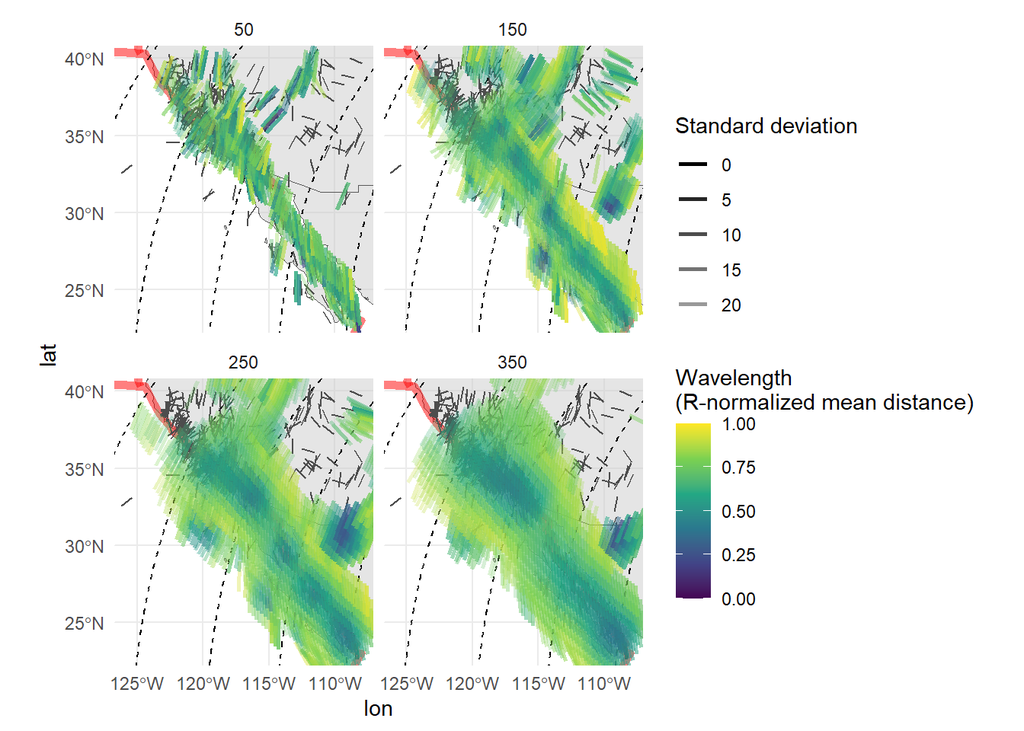

```r
map +
  geom_sf(data = trajectories, lty = 2) +
  geom_spoke(
    data = san_andreas,
    aes(lon, lat, angle = deg2rad(90 - azi)),
    radius = .5, color = "grey30", position = "center_spoke") +
  geom_spoke(
    data = mean_SH_PoR,
    aes(lon, lat, angle = deg2rad(90 - azi), alpha = sd, color = mdr),
    radius = 1, position = "center_spoke", size = 1) +
  scale_alpha(name = "Standard deviation", range = c(1, .25)) +
  scale_color_viridis_c(
    limits = c(0, 1),
    name = "Wavelength\n(R-normalized mean distance)",
    breaks = seq(0, 1, .25)
  ) +
  coord_sf(
    xlim = range(san_andreas$lon),
    ylim = range(san_andreas$lat)
  ) +
  facet_wrap(~R)
```

Considering only the data with the minimum standard deviation and the minimum radius of the search window, we can visualize the spatial distribution of the model deviation:

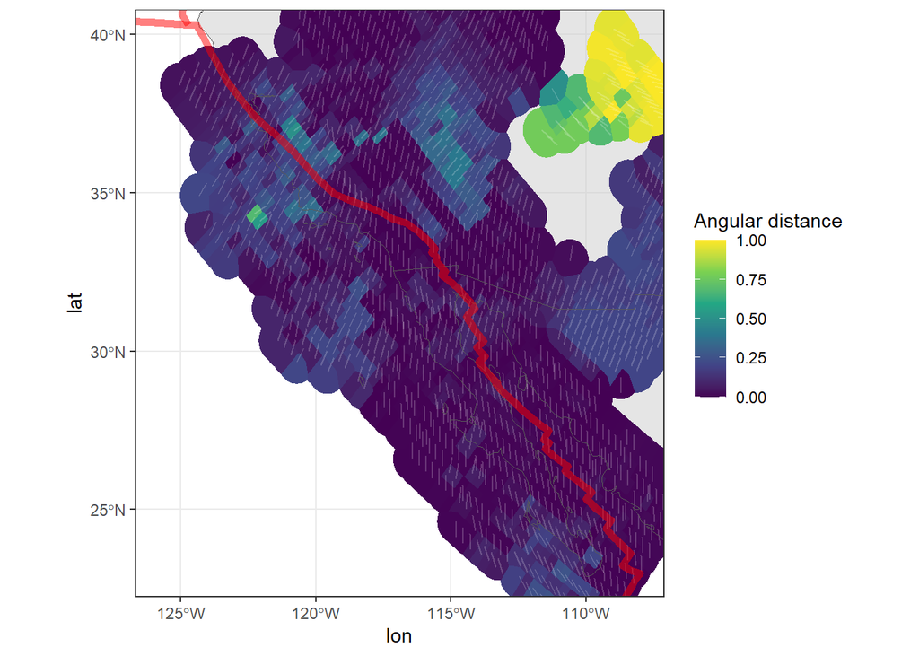

```r
mean_SH_PoR_compact <- mean_SH_PoR |>
  compact_grid() |>
  mutate(cdist = circular_distance(azi.PoR, 135))

ggplot() +
  geom_sf(data = countries, fill = "grey80", alpha = .5) +
  ggforce::geom_voronoi_tile(
    data = mean_SH_PoR_compact,
    aes(lon, lat, fill = cdist),
    max.radius = .7, normalize = FALSE) +
  geom_spoke(
    data = mean_SH_PoR_compact,
    aes(lon, lat, angle = deg2rad(90 - azi)),
    radius = .5, color = "white", alpha = .2) +
  scale_fill_viridis_c("Angular distance", limits = c(0, 1)) +
  geom_sf(data = countries, fill = NA) +
  geom_sf(
    data = plates,
    color = "red",
    lwd = 2,
    alpha = .5
  ) +
  coord_sf(
    xlim = range(san_andreas$lon),
    ylim = range(san_andreas$lat)
  ) +
  theme_bw()
```

## Exercise

Analyse the stress field of Iceland, Tibet, or a region of your choice. Analyse the dataset and consider the following questions.

- Describe the tectonic setting? Define the displacement type of the plate boundary (inward, outward, tangential)?
- Transform the stress data into the plate motion reference frame
- What is the average orientation and the variance of the transformed $\sigma_\text{Shmax}$ directions?
- Normal distribution?
- Test the significance of the predicted orientation
- How does the azimuth varies with the distance to the plate boundary?
- Calculate the theoretical stress trajectories and visualize the spatial distribution of the fit
- Interpolate the stress field and show the spatial misfit

```r
data("iceland")
# or
data("tibet")
# or
wsm2016 <- readRDS("Data/wsm2016.rds") |>
  sf::st_as_sf(coords = c("lon", "lat"), crs = "WGS84", remove = FALSE)
```

## References

Bird, Peter. 2003. “An Updated Digital Model of Plate Boundaries” *Geochemistry, Geophysics, Geosystems* 4 (3). doi: 10.1029/2001gc000252. [10.1029/2001gc000252](https://doi.org/10.1029/2001GC000252).

DeMets, C., R. G. Gordon, D. F. Argus, and S. Stein. 1990. “Current Plate Motions” *Geophysical Journal International* 101 (2): 425–78. doi: 10.1111/j.1365-246x.1990.tb06579.x.

Heidbach, Oliver; Rajabi, Mojtaba; Reiter, Karsten; Ziegler, Moritz; and WSM Team. 2016. “World Stress Map Database Release 2016. V. 1.1.” GFZ Data Services. doi: 10.5880/WSM.2016.001.